# Liigikaaslaste munade mõju pruun-kuldtiiva (*Lycaena tityrus*) munemistaime eelistusele

Laura Tammiste

22.10.2020

# 1. Katsete ja andmestiku kirjeldus

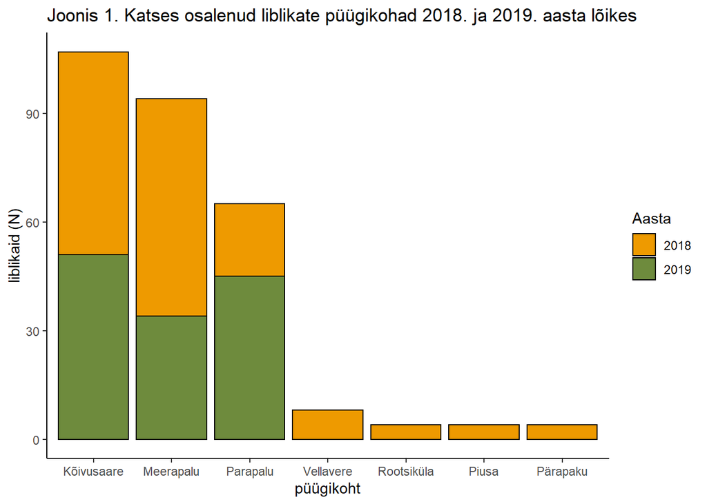

Katses kasutati nelja eri taimemanipulatsiooni (“trea”):

- munadega taim (VS) - katse eel oli teine liblikas taimele munenud;
- eemaldatud munadega taim (S) - nagu munadega taim, kuid millelt oli vahetult enne katset munad eemaldatud;
- kleebitud munadega taim (V) - liblikatega eelnevalt mitte kokku puutunud taim, millele oli kleebitud kahepoolse läbipaistva teibiga mõne teise emase munetud munad;
- kontrolltaim (C) - munad ja eelnev kokkupuude liblikatega puudusid.

|  | X.U.FEFF.katsenr | liblikas | aasta | puugikoht | puugikp | tiivapikkus | alguskaal | loppkaal | algusaeg | louna | lopuaeg | katsekp | temp | trea | trea2 | taimeID | taimeh | lehti | muneenne | munejuurdelounal | munejuurde | mujalemunetudmunad |
| --- | --- | --- | --- | --- | --- | --- | --- | --- | --- | --- | --- | --- | --- | --- | --- | --- | --- | --- | --- | --- | --- | --- |
| 1 | 1 | LT2 | 2018 | Vellavere | 18.07.2018 | 17 | 42.2 | 41.6 | 10:50:00 |  | 19:00:00 | 19.07.2018 | 29 | VS |  | RA1 | 11 | 11 | 7 |  | 2 |  |
| 2 | 1 | LT2 | 2018 | Vellavere | 18.07.2018 | 17 | 42.2 | 41.6 | 10:50:00 |  | 19:00:00 | 19.07.2018 | 29 | S |  | RA2 | 9.5 | 20 | 15 |  | 0 |  |
| 3 | 1 | LT2 | 2018 | Vellavere | 18.07.2018 | 17 | 42.2 | 41.6 | 10:50:00 |  | 19:00:00 | 19.07.2018 | 29 | V |  | RA3 | 9.5 | 8 | 7 |  | 0 |  |
| 4 | 1 | LT2 | 2018 | Vellavere | 18.07.2018 | 17 | 42.2 | 41.6 | 10:50:00 |  | 19:00:00 | 19.07.2018 | 29 | C |  | RA15 | 8 | 13 | 0 |  | 0 |  |
| 5 | 2 | LT1 | 2018 | Vellavere | 16.07.2018 | 17 | 44.1 | 38 | 11:20:00 |  | 19:30:00 | 21.07.2018 | 29 | VS |  | RA1 | 11 | 11 | 8 |  | 2 |  |
| 6 | 2 | LT1 | 2018 | Vellavere | 16.07.2018 | 17 | 44.1 | 38 | 11:20:00 |  | 19:30:00 | 21.07.2018 | 29 | S |  | RA2 | 9.5 | 16 | 15 |  | 3 |  |
| 7 | 2 | LT1 | 2018 | Vellavere | 16.07.2018 | 17 | 44.1 | 38 | 11:20:00 |  | 19:30:00 | 21.07.2018 | 29 | V |  | RA3 | 9.5 | 8 | 8 |  | 3 |  |
| 8 | 2 | LT1 | 2018 | Vellavere | 16.07.2018 | 17 | 44.1 | 38 | 11:20:00 |  | 19:30:00 | 21.07.2018 | 29 | C |  | RA15 | 8 | 13 | 0 |  | 0 |  |
| 9 | 3 | LT3 | 2018 | Rootsiküla | 22.07.2018 | 18 | 56 | 52.8 | 11:40:00 |  | 19:50:00 | 23.07.2018 | 28 | VS |  | RA1 | 11 | 11 | 9 |  | 2 |  |
| 10 | 3 | LT3 | 2018 | Rootsiküla | 22.07.2018 | 18 | 56 | 52.8 | 11:40:00 |  | 19:50:00 | 23.07.2018 | 28 | S |  | RA2 | 9.5 | 16 | 17 |  | 6 |  |

[output cut: 280 more lines]

Eesmärk on teada saada, kas mõnda taimetöötlust on munemiseks rohkem või vähem eelistatud kui teisi. Selleks peab uurima, kas on erinevusi munetud munade arvus taimetöötluste vahel. Et välistada taimede enda tunnuste mõju munemiseelistusele, peab uurima ka seda, kas taime suurus või taime lehtede arv mõjutas munemistaime eelistust.Samuti pakub andmestikus huvi see, kas leidub korrelatsioone erinevate tunnuste vahel.

Katsed viidi läbi katsekastides, kuhu pandi vastava töötlusega taimed, suhkrulahusega immutatud salvrätik liblikale toiduks ning kõige lõpus lasti kasti ka katses osalev liblikas. Katse kestis 8 h, mille järel loeti taimedele juurde munetud munad üle. Mõndasid liblikaid kasutati katseperioodi jooksul mitu korda. Katsedisainid erinesid 2018. ja 2019. aastatel. 2018. aastal oli üheks replikaadiks neli taimetöötlust ja liblikas, kuid 2019. aastal oli üheks replikaadiks üks liblikas ühe juhuslikult valitud taimetöötlusega. Lisaks hoiti 2019. aastal lisatöötlusena (“trea2”) osasid liblikaid aklimatiseerumispäeval grupiti koos ning teisi üksikult, et vaadata, kas populatsiooni tiheduse kasvu imiteerides muutub ka munemiseelistus.

# 2. Andmete analüüs

Peaaegu kõikide 2019. aastal katsetes osalenud liblikatega viidi katsed läbi kaks korda, kus kahe katsepäeva vahel oli aklimatiseerumispäev. Ka 2018. aastal kasutati mõndasid liblikaid katsetes mitu korda.Seega tuleb kogu andmestiku analüüsil vältida pseudoreplikatsiooni, võttes analüüsil arvesse ka seda mitmendat korda liblikas kastes oli.

## 2.1. Katses osalenud liblikad ja katsetingimused

Katses osalenud liblikate keskmine parema tiiva pikkus oli 16.1 mm. Keskmine liblikate kaal enne katse algust oli 43.75 g ning katse lõpus 43.22. Katses osalemine ei mõjutanud liblikate kaalu (*paired t-test* p =0.19). Liblikad olid enne katse algust laboris veetnud keskmiselt 3.13 päeva. Keskmiselt kestis üks katse 7.98 tundi. Keskmine temperatuur katsekastides oli 28.5 $^\circ$C.

## 2.2. Katses osalenud taimed

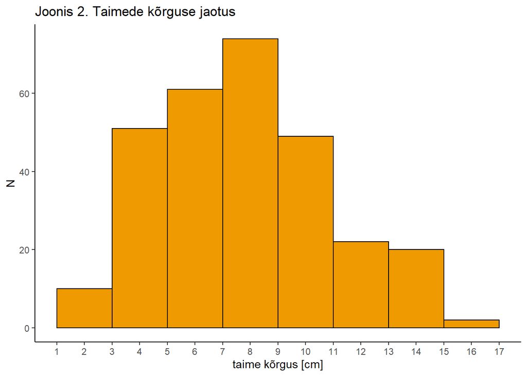

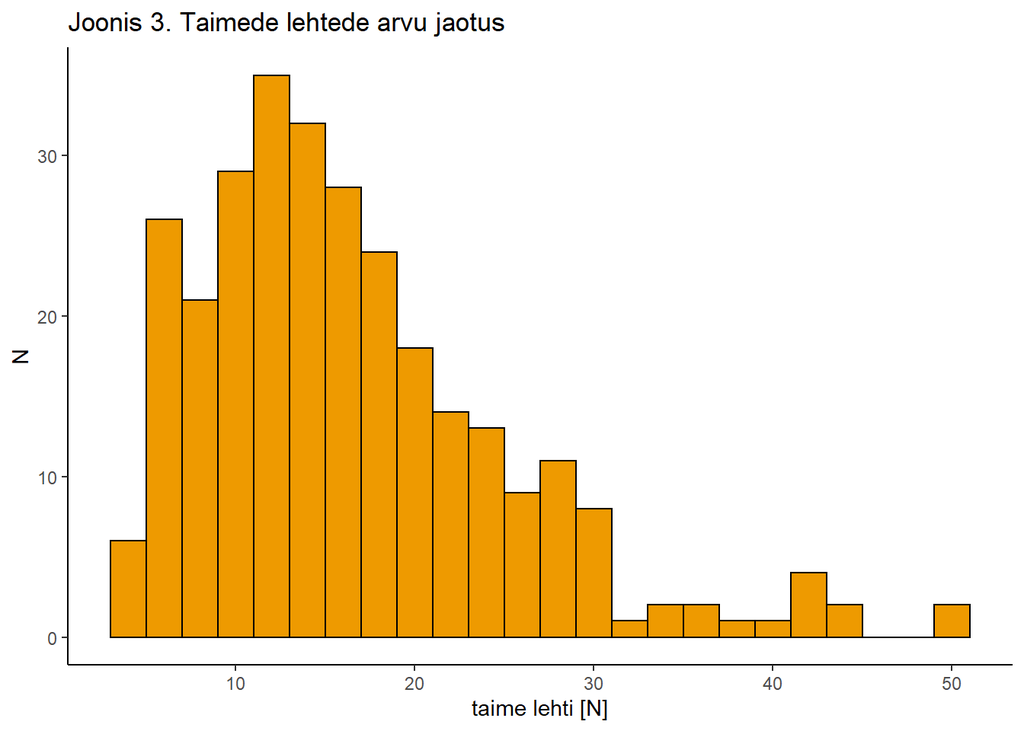

## 2.3. Juurde munetud munade arv

Kõikidest katsetest munesid emasliblikad 58.3 % korral. Keskmiselt oli töötlusega taimedel enne mune 13.1527778 (mediaan = 10). Keskmine juurde munetud munade arv kõikide taimetöötluste lõikes oli 9.9585799 (mediaan = 6). Juurde munetud munade arv allub Poissoni jaotusele (Joonis 4.).

[figure not shown]

### 2.3.1 Taime töötluse mõju munemiseelistusele

|  | trea | aasta | keskmine | mediaan | max | n |
| --- | --- | --- | --- | --- | --- | --- |
| 1 | C | 2018 | 1.73 | 0 | 13 | 40 |
| 2 | S | 2018 | 3.17 | 1 | 18 | 40 |
| 3 | V | 2018 | 0.9 | 0 | 10 | 40 |
| 4 | VS | 2018 | 2.6 | 1.5 | 15 | 40 |

|  | trea | aasta | keskmine | mediaan | max | n |
| --- | --- | --- | --- | --- | --- | --- |
| 1 | C | 2019 | 10.78 | 5 | 47 | 23 |
| 2 | S | 2019 | 17.39 | 15.5 | 49 | 18 |
| 3 | V | 2019 | 11.33 | 7.5 | 40 | 18 |
| 4 | VS | 2019 | 11.88 | 7 | 36 | 16 |

Seega oli 2018. aastal ühele taimele munetud munade arv suurusjärgu võrra madalam, mis on ilmselt mõjutatud sellest, et 2018. aastal oli liblikal korraga valida nelja erineva taime vahel. Samas kui 209. aastal oli liblikas ühe taimega koos ning tal oli valida, kas ta muneb sellele taimele või mitte. Mõlema aasta puhul on aga näha, et keskmine munetud munade arv eemaldatud munadega taimedel on teistest taimetöötlustest kõrgem. Ka 2019. aasta teisel katsekorral on keskmine munade arv munadega taimedel kõrgem (Tabel 4). Samuti on veidi kõrgem munade arv munadega taimedel 2018. aasta esimestekatsete hulgas ning 2019. aasta teisel katsekorral. Kas keskmiste munetud munade hulkade vahe ka statistiliselt oluliseks tuleb, on vaja testida keerulistemate mudelitega, mida siin töös ei käsitleta.

|  | trea | aasta | keskmine | mediaan | n |
| --- | --- | --- | --- | --- | --- |
| 1 | C | 2019 | 2.27 | 0 | 11 |
| 2 | S | 2019 | 11.06 | 13 | 17 |
| 3 | V | 2019 | 5.71 | 1.5 | 14 |
| 4 | VS | 2019 | 7.62 | 4 | 13 |

Järgnevalt uurin vaid nende katsete andmeid, mille jooksul liblikad hakkasid munema.

|  | trea | munes | n |
| --- | --- | --- | --- |
| 1 | C | 0 | 24 |
| 2 | C | 1 | 16 |
| 3 | S | 0 | 16 |
| 4 | S | 1 | 24 |
| 5 | V | 0 | 27 |
| 6 | V | 1 | 13 |
| 7 | VS | 0 | 12 |
| 8 | VS | 1 | 28 |

|  | trea | munes | n |
| --- | --- | --- | --- |
| 1 | C | 0 | 8 |
| 2 | C | 1 | 15 |
| 3 | S | 0 | 2 |
| 4 | S | 1 | 16 |
| 5 | V | 0 | 4 |
| 6 | V | 1 | 14 |
| 7 | VS | 0 | 6 |
| 8 | VS | 1 | 10 |

|  | trea | munes | n |
| --- | --- | --- | --- |
| 1 | C | 0 | 16 |
| 2 | C | 1 | 18 |
| 3 | S | 0 | 7 |
| 4 | S | 1 | 28 |
| 5 | V | 0 | 9 |
| 6 | V | 1 | 23 |
| 7 | VS | 0 | 10 |
| 8 | VS | 1 | 19 |

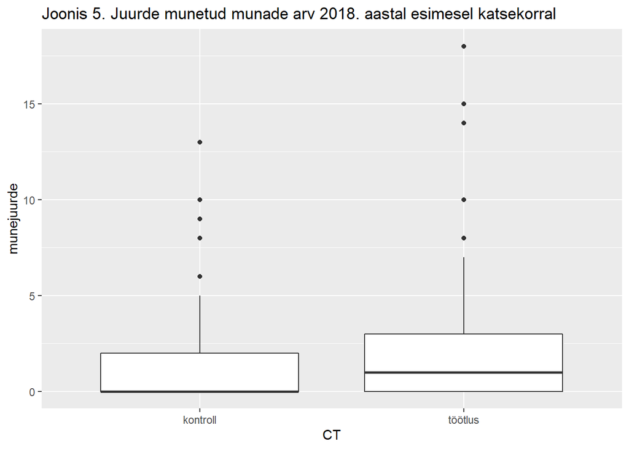

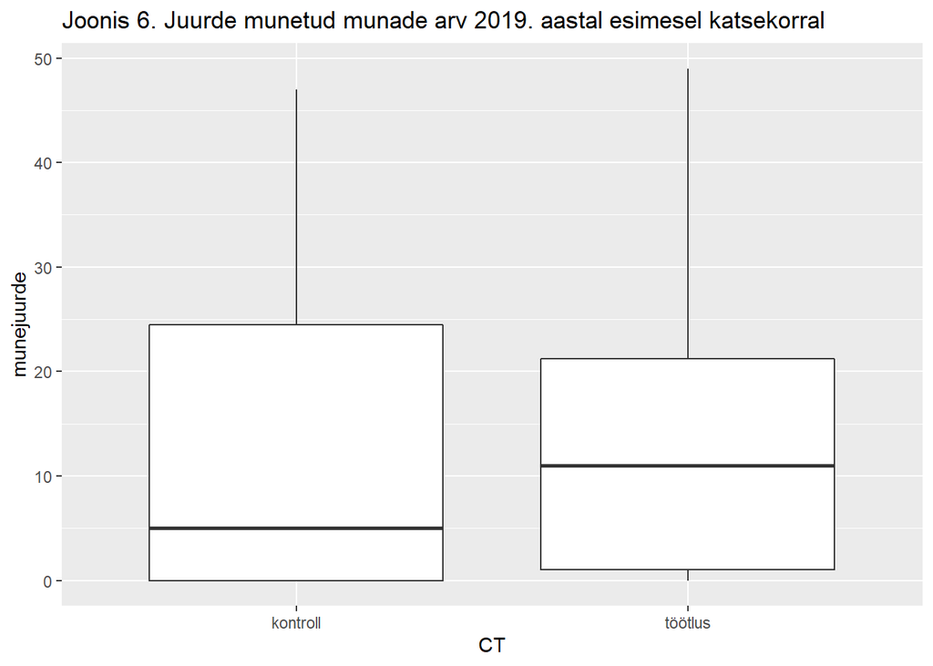

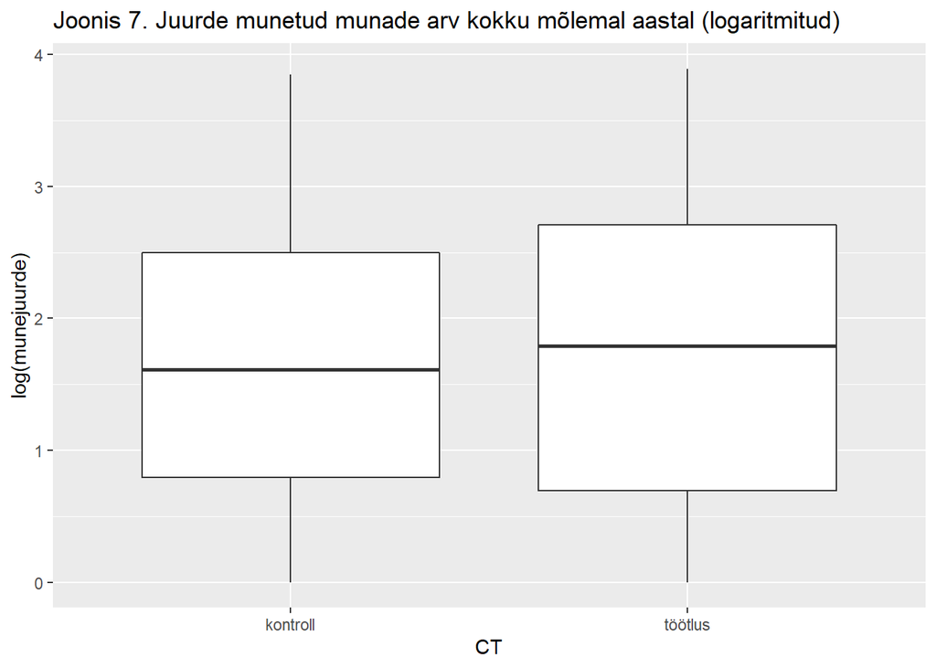

### 2.3.2. Taime tunnuste mõju munemiseelistusele

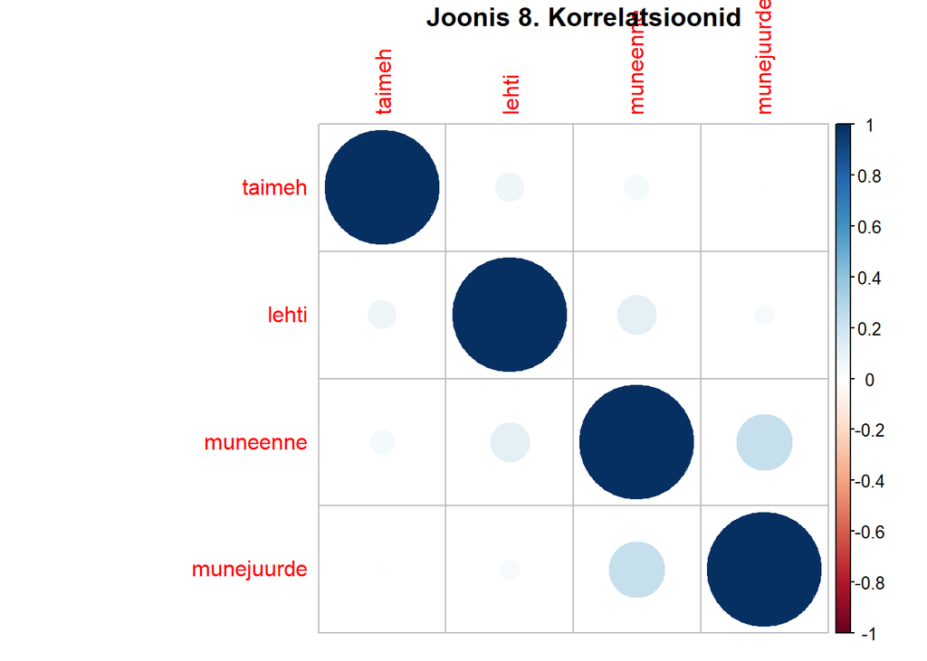

Taimede kõrgus ning taime lehtede arv ei korreleerunud kumbki juurde munetud munade arvuga (Joonis 8.-10., taime kõrgus ja juurde munetud munade arv p = 0.92, lehtede arv ja juurde munetud munade arv p = 0.6). Küllaga korreleerusid omavahel enne katset taimele munetud munade arv ja taime lehtede arv (p = 0.04). Samuti korrelleerub omavahel juurde munetud munade arv ja taimel enne katset olnud munade arv (p = 3.750871110^{-5}).

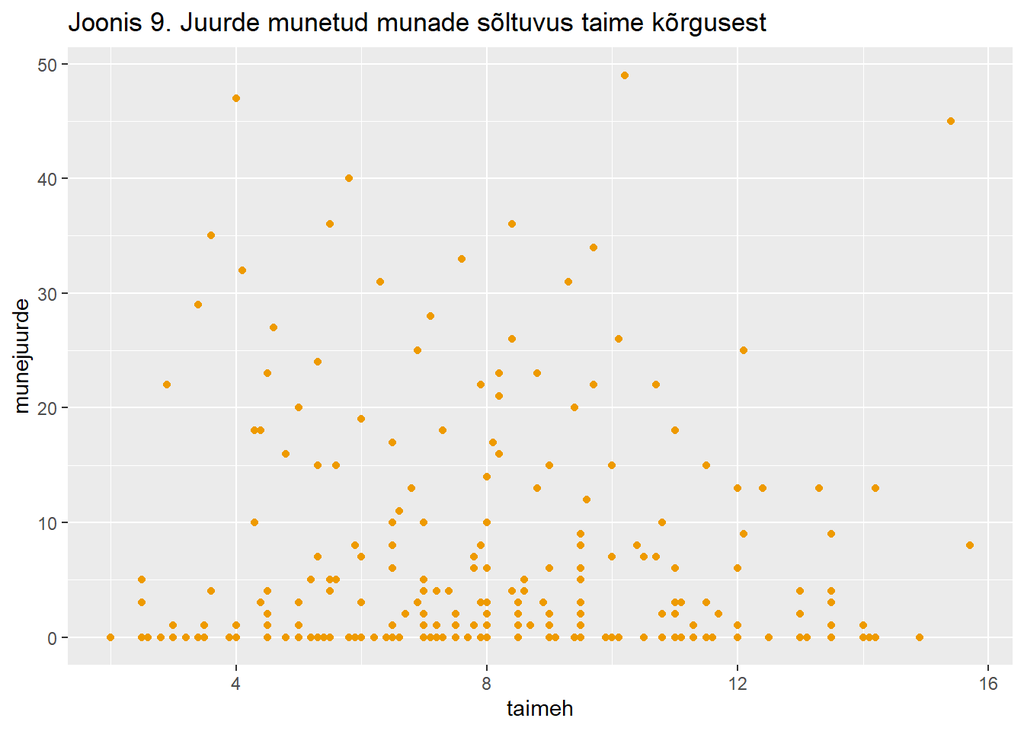

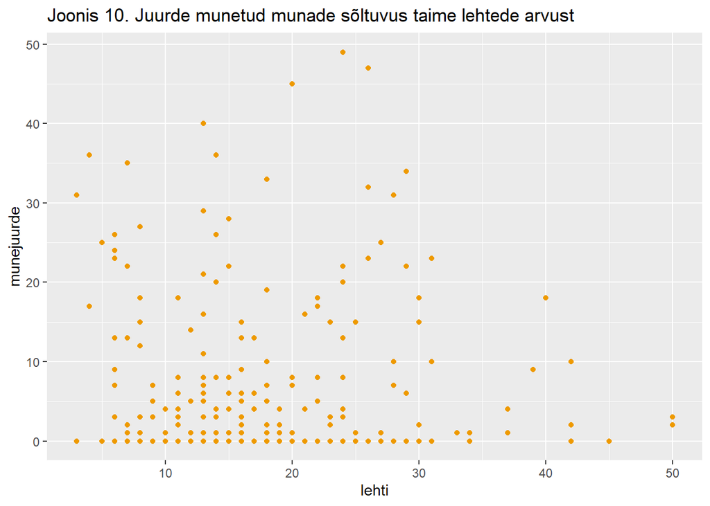